# Data Carpentry’s Pilot Pre-Workshop Survey

### Summary of Current Responses

**Lead**: [Kari L. Jordan](https://github.com/kariljordan)  
**Revised**: 2017-10-20

Data Carpentry is piloting a pre/post workshop survey that includes skills-based questions. A [PDF](https://github.com/carpentries/assessment/blob/master/data-carpentry/preworkshop/2017-pilot/presurvey.pdf) of the survey questions, the data used in this analysis, and full R code are located on the Data Carpentry [assessment](https://github.com/carpentries/assessment/tree/master/data-carpentry/preworkshop/2017-pilot) repo on GitHub. Feel free to use the data and tell us about your findings.

The following is a summary of the responses that have been collected since March 2017. As of 2017-10-20, 261 responses have been collected for the [pre-workshop survey](https://github.com/carpentries/assessment/blob/master/data-carpentry/preworkshop/2017-pilot/presurvey.pdf).

# Demographics

### Domain

| Domain (Check all that apply) | n | % |
| --- | --- | --- |
| Life Sciences | 64 | 20.6 |
| Agricultural or Environmental Sciences | 62 | 20.0 |
| Bioinformatics/Genomics | 40 | 12.9 |
| Biomedical/Health Sciences | 27 | 8.7 |
| Social Sciences | 27 | 8.7 |
| Mathematics or Statistics | 22 | 7.1 |
| Engineering | 18 | 5.8 |
| Computer Science | 14 | 4.5 |
| Humanities | 14 | 4.5 |
| Business | 6 | 1.9 |
| Library Sciences | 6 | 1.9 |
| Earth Sciences | 5 | 1.6 |
| Physical Sciences | 5 | 1.6 |

### Status

| Status (Check all that apply) | n | % |
| --- | --- | --- |
| Graduate Student | 102 | 47.9 |
| Research Staff | 35 | 16.4 |
| Faculty | 23 | 10.8 |
| Postdoctoral Researcher | 15 | 7.0 |
| Other Staff | 12 | 5.6 |
| Government Employee | 11 | 5.2 |
| Undergraduate Student | 9 | 4.2 |
| Industry Employee | 6 | 2.8 |

### Operating System

| Operating System | n | % |
| --- | --- | --- |
| Windows | 124 | 58.8 |
| Apple/Mac OS | 76 | 36.0 |
| GNU/Linux | 9 | 4.3 |
| Not sure | 2 | 0.9 |

### Programming Usage

How often do you currently use programming languages (R, Python, etc.) databases (Access, SQL, etc.) version control software or the Unix shell?

| Current Programming Usage | n | % |
| --- | --- | --- |
| I have never used these tools | 57 | 27.0 |
| Several times a year | 42 | 19.9 |
| Weekly | 29 | 13.7 |
| Daily | 28 | 13.3 |
| Less than once a year | 26 | 12.3 |
| Monthly | 20 | 9.5 |
| Not sure | 9 | 4.3 |

### Satisfaction with Data

Please rate your level of satisfaction with your current data management and analysis workflow.

| Satisfaction | n | % |
| --- | --- | --- |
| Neutral | 71 | 33.8 |
| Not applicable | 11 | 5.2 |
| Not sure | 14 | 6.7 |
| Satisfied | 26 | 12.4 |
| Unsatisfied | 63 | 30.0 |
| Very satisfied | 5 | 2.4 |
| Very unsatisfied | 20 | 9.5 |

### Perception of Attendance

Why are you attending this workshop?

| Why are you attending? Check all that apply. | n | % |
| --- | --- | --- |
| To learn skills that I can apply to my current work | 178 | 40.0 |
| To learn skills that I can apply to my work in the future | 172 | 38.7 |
| To learn skills that will help me get a job | 80 | 18.0 |
| As a requirement for my program/current position | 15 | 3.4 |

### Workshop Exposure

How did you find out about this workshop?

| Exposure | n | % |
| --- | --- | --- |
| Received an email about the workshop | 119 | 49.0 |
| My friend/colleague told me about it | 53 | 21.8 |
| My advisor/supervisor told me about it | 47 | 19.3 |
| Read about it in a newsletter or university web site | 13 | 5.3 |
| Other web site | 7 | 2.9 |
| Twitter or other social media | 4 | 1.6 |

### Programming Language Covered

Which programming language is being covered?

| Which language is being covered? | n | % |
| --- | --- | --- |
| R | 166 | 77.6 |
| I don’t know/I don’t remember | 28 | 13.1 |
| Python | 17 | 7.9 |
| Neither | 3 | 1.4 |

# Skills Based Questions

### Question 1

Which of the following are fundamental rules for producing well formatted spreadsheet tables? Check all that apply.

*Objective*: Describe best practices for data entry and formatting in spreadsheets.

The answers they should’ve checked are:

- Put each variable (e.g. ‘weight’ or ‘temperature’) in its own column.
- Put each observation in its own row.
- Leave the raw data raw and make edits to a copy of the data.

The majority of the respondents selected these three options.

Matrix of Fundamental Formatting Rules

| Fundamental Rules for Spreadsheets | n | % |
| --- | --- | --- |
| Put each variable (e.g. ‘weight’ or ‘temperature’) in its own column. | 121 | 33.1 |
| Leave the raw data raw and make edits to a copy of the data. | 106 | 29.0 |
| Put each observation in its own row. | 105 | 28.7 |
| Place comments alongside data values within a single cell, so they don’t get separated. | 26 | 7.1 |
| Combine related pieces of information in one cell. | 8 | 2.2 |

|  | Combine related pieces of information in one cell. | Leave the raw data raw and make edits to a copy of the data. | Place comments alongside data values within a single cell, so they don’t get separated. | Put each observation in its own row. | Put each variable (e.g. ‘weight’ or ‘temperature’) in its own column. |
| --- | --- | --- | --- | --- | --- |
| Combine related pieces of information in one cell. | 8 | 8 | 4 | 6 | 7 |
| Leave the raw data raw and make edits to a copy of the data. | 8 | 106 | 22 | 90 | 103 |
| Place comments alongside data values within a single cell, so they don’t get separated. | 4 | 22 | 26 | 22 | 26 |
| Put each observation in its own row. | 6 | 90 | 22 | 105 | 101 |
| Put each variable (e.g. ‘weight’ or ‘temperature’) in its own column. | 7 | 103 | 26 | 101 | 121 |

### Question 2

*Objective*: Apply best practices to arrange variables and observations in a spreadsheet.

The following spreadsheet table shows data from a survey of teenagers’ favorite fruit. Multiple researchers have entered data into the spreadsheet keeping track of date collected, school code, age, sex, and favorite fruit.

| Date Collected | School Code | Age-Sex | Favorite Fruit |  |
| --- | --- | --- | --- | --- |
| 1/19/17 | 01 | 15-M | orange |  |
| 1/19/17 | 01 | 17-F | apple |  |
| 1/19/17 | 01 | 18-F | grapes |  |
| 1/20/17 | 01 | 16-F | banana |  |
| 1/20/17 | 02 | 14-M | pear |  |
| 1/20/17 | 02 | 17-F | mango |  |
| 3/13/17 | 02 | 15-F | kiwi |  |
| 3/13/17 | 02 | 18-F | peach |  |
| 3/13/17 | 02 | 16-F | strawberries |  |

We want to know if respondents understand how to structure data in a spreadsheet. We asked which table most improves the structure of this data.

The correct answser is B, which is a spreadsheet table that separates the variables as follows:

Year | Month | Day | School Code | Age | Sex | Favorite Fruit |

The majority of respondents selected B, with about a third selecting C. C separated the variables as follows:

Date collected | School Code | Age | Sex | Favorite Fruit |

| Which improves data structure? | n | % |
| --- | --- | --- |
| A | 1 | 0.8 |
| B | 81 | 61.4 |
| C | 47 | 35.6 |
| None of the tables above improve the structure of the data. | 3 | 2.3 |

### Question 3

*Objective*: Load external data from a csv file into a dataframe in R.

How can you read this data into R, creating the dataframe ‘contacts’, so that you can work with the data in R?

| Reading in data | n | % |
| --- | --- | --- |
| A: contacts <- read.csv(“data.txt”) | 10 | 9.5 |
| B: contacts <- read.csv(“data.txt”, header = TRUE, sep = “,”) | 26 | 24.8 |
| C: contacts <- read.table(“data.txt”) | 5 | 4.8 |
| D: contacts <- read.table(“data.txt”, header = TRUE, sep = “,”) | 27 | 25.7 |
| Options A and C will both work. | 14 | 13.3 |
| Options A, B and D will all work. | 23 | 21.9 |

### Question 4

*Objective*: Load external data from a csv file into a dataframe in R.

Which of the following options complete the blanks in the statement below to make a true statement. Check all that apply.

Answer A in the previous question ____, because ___.

*This is a check all that apply question, but in the current survey version it’s only single select*

| Which improves data structure? | n | % |
| --- | --- | --- |
| will NOT work, the data doesn’t have headers | 2 | 2.0 |
| will NOT work, the data isn’t a csv file | 27 | 27.3 |
| will NOT work, you need to specify options for all parameters to a function | 29 | 29.3 |
| will work, the data is a csv file with headers | 41 | 41.4 |

### Question 5

*Objective*: Checking integrity of loaded data in R

After you load data into a dataframe, what are some things you can do to check that it was imported correctly? Check all that apply.

Of the options, respondents should’ve selected:

- Type the name of the data frame to display the whole dataset.
- Use the str() function to see information about the data.
- Use the dim() function to see the number of rows and columns in the dataset.

The head() function gives you the first few lines, not the last.

Matrix of Checking Data Import

| Checking data imported correctly | n | % |
| --- | --- | --- |
| Type the name of the data frame to display the whole dataset. | 59 | 31.4 |
| Use the str() function to see information about the data. | 54 | 28.7 |
| Use the dim() function to see the number of rows and columns in the dataset. | 46 | 24.5 |
| Use the head() function to see the last few lines of the data. | 29 | 15.4 |

|  | Type the name of the data frame to display the whole dataset. | Use the dim() function to see the number of rows and columns in the dataset. | Use the head() function to see the last few lines of the data. | Use the str() function to see information about the data. |
| --- | --- | --- | --- | --- |
| Type the name of the data frame to display the whole dataset. | 59 | 33 | 15 | 27 |
| Use the dim() function to see the number of rows and columns in the dataset. | 33 | 46 | 17 | 26 |
| Use the head() function to see the last few lines of the data. | 15 | 17 | 29 | 19 |
| Use the str() function to see information about the data. | 27 | 26 | 19 | 54 |

### Question 6

*Objective*: Produce a simple plot in R using ggplot.

If ‘df’ is your dataframe and has columns x and y, which of the follwing lines of code will produce a plot of x versus y?

| Which produces plot x vs. y? | n | % |
| --- | --- | --- |
| A: ggplot <- df | 2 | 2.1 |
| B: ggplot(df) | 8 | 8.2 |
| C: ggplot(df, aes(x, y)) | 35 | 36.1 |
| D: ggplot(df, aes(x, y)) + geom_point() | 35 | 36.1 |
| None of the above will work. | 17 | 17.5 |

### Question 7

Which of the following options complete the blanks in the statement below to make a true statement. Check all that apply.

Answer C in the previous question ____, because ___.

Matrix of Plotting Reasoning Question

| Reasoning | n | % |
| --- | --- | --- |
| will NOT work, you need to specify the type of plot that you want. | 45 | 48.4 |
| will work, it contains all of the necessary information. | 43 | 46.2 |
| will NOT work, you need to specify a size for the points in your plot. | 4 | 4.3 |
| will NOT work, you need to specify a color for the points in your plot. | 1 | 1.1 |

|  | will NOT work, you need to specify a color for the points in your plot. | will NOT work, you need to specify a size for the points in your plot. | will NOT work, you need to specify the type of plot that you want. | will work, it contains all of the necessary information. |
| --- | --- | --- | --- | --- |
| will NOT work, you need to specify a color for the points in your plot. | 1 | 0 | 0 | 0 |
| will NOT work, you need to specify a size for the points in your plot. | 0 | 4 | 1 | 0 |
| will NOT work, you need to specify the type of plot that you want. | 0 | 1 | 45 | 0 |
| will work, it contains all of the necessary information. | 0 | 0 | 0 | 43 |

# Perception of Confidence, Motivation, and Tools

Respondents were asked to rate their level of agreement (1-Strongly disagree to 5-Strongly agree) with the statements below. The following heat map and Likert plot shows respondents’ answers. The x-axis labels for the figure are in bold, and correspond to the statement following.

- **WriteProgram**: I can write a small program/script/macro to solve a problem in my own work.
- **SearchAnswers**: I know how to search for answers to my technical questions online.
- **Reproducible**: Using a programming language (like R or Python) can make my analyses easier to reproduce.
- **RawData**: Having access to the original, raw data is important to be able to repeat an analysis.
- **Overcoming**: While workng on a programming project, if I get stuck, I can find ways of overcoming the problem.
- **Confidence**: I am confident in my ability to make use of programming languages to work with data.

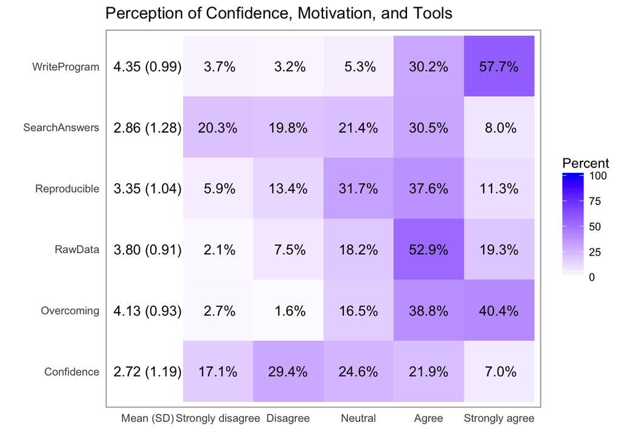

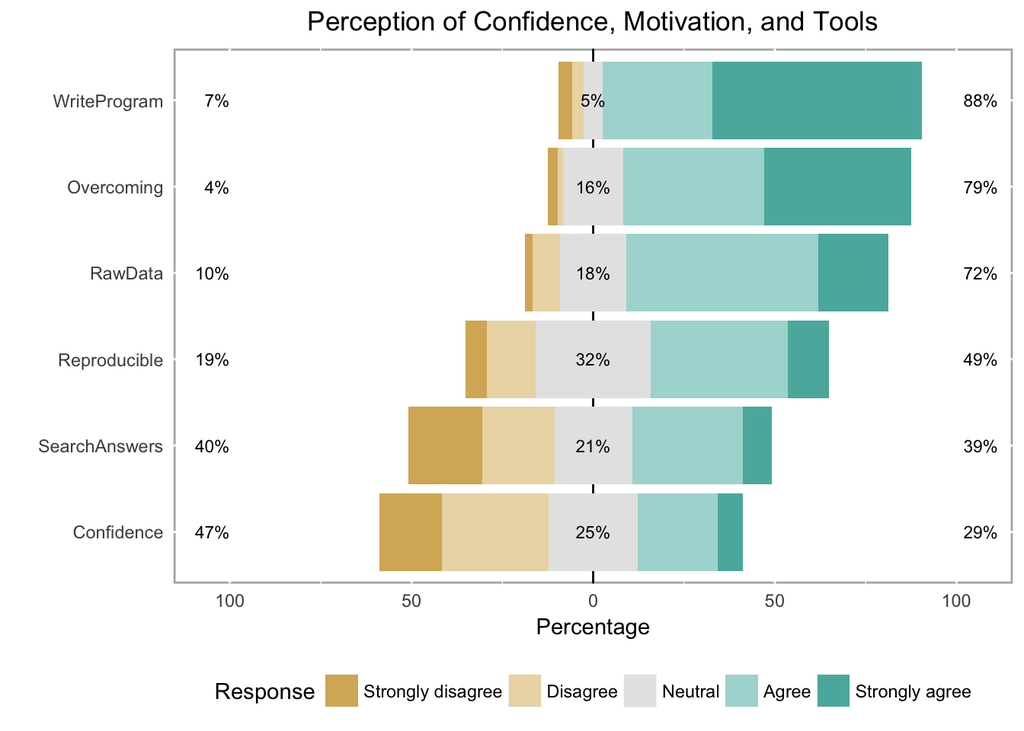

[output not shown]